# GES 001 演習2, Part II

H. Suzuki

2023年12月19日`

```r
library(tidyverse)
library(WDI)
#library(showtext)
```

## データの読み込み（2）

総人口 Population, total：SP.POP.TOTL

出生率（千人）Birth rate, crude (per 1,000 people)：SP.DYN.CBRT.IN

死亡率（千人）Death rate, crude (per 1,000 people)：SP.DYN.CDRT.IN

若年労働人口率 Age dependency ratio, young (% of working-age population)：SP.POP.DPND.YG

高齢者労働人口率 Age dependency ratio, old (% of working-age population)：SP.POP.DPND.OL

```r
df_pop_related <- WDI(indicator = c(pop = "SP.POP.TOTL",
                            birth_rate = "SP.DYN.CBRT.IN",
                            death_rate = "SP.DYN.CDRT.IN",
                            young = "SP.POP.DPND.YG",
                            old = "SP.POP.DPND.OL"))
```

## 保存と読み込み

```r
write_csv(df_pop_related, "data/pop_related.csv")
```

```r
df_pop_related <- read_csv("data/pop_related.csv")
```

## データの確認

```r
head(df_pop_related)
```

| country | iso2c | iso3c | year | pop | birth_rate | death_rate | young | old |
| --- | --- | --- | --- | --- | --- | --- | --- | --- |
| Afghanistan | AF | AFG | 1960 | 8622466 | 50.340 | 31.921 | 74.95021 | 5.100901 |
| Afghanistan | AF | AFG | 1961 | 8790140 | 50.443 | 31.349 | 75.14425 | 5.078088 |
| Afghanistan | AF | AFG | 1962 | 8969047 | 50.570 | 30.845 | 75.35238 | 5.049558 |
| Afghanistan | AF | AFG | 1963 | 9157465 | 50.703 | 30.359 | 75.69330 | 5.022020 |
| Afghanistan | AF | AFG | 1964 | 9355514 | 50.831 | 29.867 | 76.21984 | 4.999719 |
| Afghanistan | AF | AFG | 1965 | 9565147 | 50.872 | 29.389 | 77.00953 | 4.985287 |

## データの構造（Structure）

```r
str(df_pop_related[])
```

```
tibble [16,758 × 9] (S3: tbl_df/tbl/data.frame)
 $ country   : chr [1:16758] "Afghanistan" "Afghanistan" "Afghanistan" "Afghanistan" ...
 $ iso2c     : chr [1:16758] "AF" "AF" "AF" "AF" ...
 $ iso3c     : chr [1:16758] "AFG" "AFG" "AFG" "AFG" ...
 $ year      : num [1:16758] 1960 1961 1962 1963 1964 ...
 $ pop       : num [1:16758] 8622466 8790140 8969047 9157465 9355514 ...
 $ birth_rate: num [1:16758] 50.3 50.4 50.6 50.7 50.8 ...
 $ death_rate: num [1:16758] 31.9 31.3 30.8 30.4 29.9 ...
 $ young     : num [1:16758] 75 75.1 75.4 75.7 76.2 ...
 $ old       : num [1:16758] 5.1 5.08 5.05 5.02 5 ...
```

## 変形

wide データを long データに変形します。いずれ説明します。

```r
df_pop_long <- df_pop_related |>
  pivot_longer(pop:old, names_to = "name", values_to = "value")
```

## 出生率と死亡率

出生率（千人）Birth rate, crude (per 1,000 people)：SP.DYN.CBRT.IN [[Link](https://data.worldbank.org/indicator/SP.DYN.CBRT.IN)]

死亡率（千人）Death rate, crude (per 1,000 people)：SP.DYN.CDRT.IN [[Link](https://data.worldbank.org/indicator/SP.DYN.CDRT.IN)]

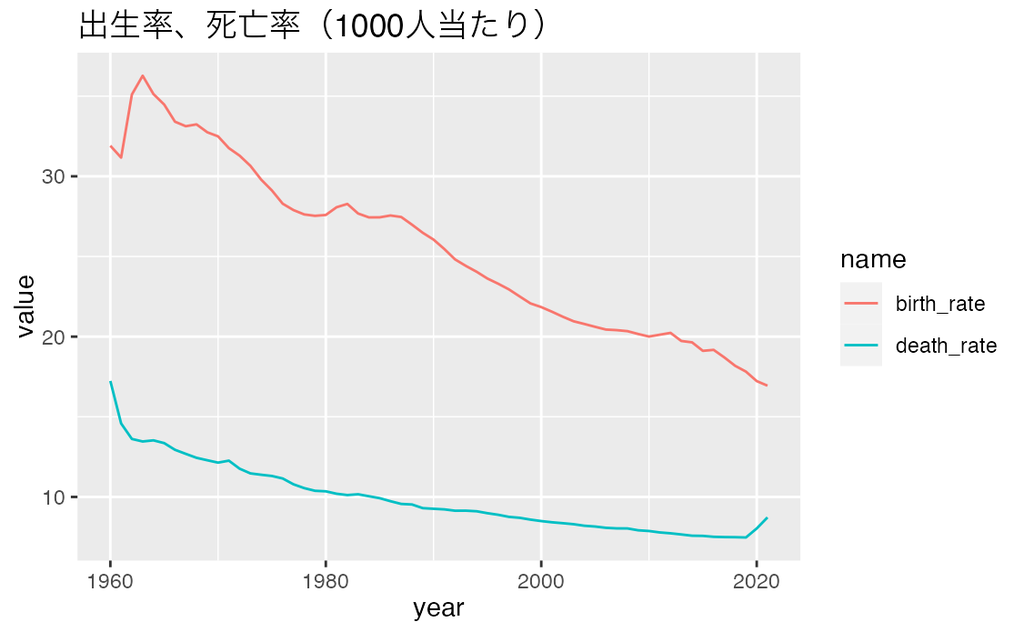

```r
df_pop_long |> filter(name %in% c("birth_rate", "death_rate")) |>
  filter(country == "World") |> drop_na(value) |> # NA value を削除
  ggplot(aes(year, value, col = name)) + geom_line() +
  labs(title = "出生率、死亡率（1000人当たり）")
```

**練習5 国を選択して、出生率、死亡率のグラフを描いてください。**

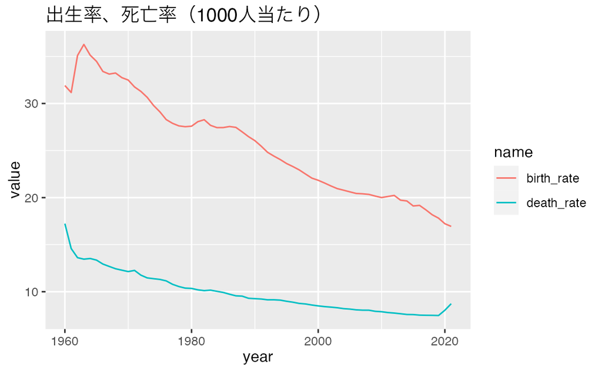

```r
df_pop_long |> filter(name %in% c("birth_rate", "death_rate")) |>
  filter(country == "World") |> drop_na(value) |> # NA value を削除
  ggplot(aes(year, value, col = name)) + geom_line() +
  labs(title = "出生率、死亡率（1000人当たり）")
```

```r
df_pop_long |> filter(name %in% c("birth_rate", "death_rate")) |>
  filter(iso2c %in% c("BD", "BR", "CN", "ID", "NG", "JP")) |> drop_na(value) |>
  ggplot(aes(year, value, col = country, linetype = name)) +
  geom_line() + labs(title = "国々の、出生率、死亡率（1000人当たり）")
```

[output not shown]

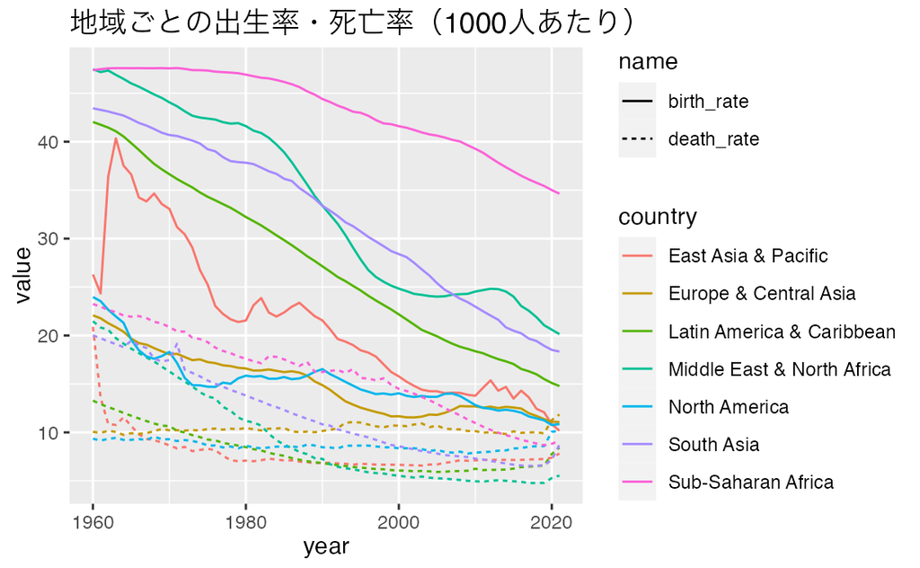

```r
df_pop_long |> filter(name %in% c("birth_rate", "death_rate")) |>
  filter(iso2c %in% c("Z4", "Z7", "ZJ", "ZQ", "XU", "8S", "ZG")) |> drop_na() |>
  ggplot(aes(year, value, col = country, linetype = name)) +
  geom_line() + labs(title = "地域ごとの出生率・死亡率（1000人あたり）")
```

```r
df_pop_long |> filter(name %in% c("birth_rate", "death_rate")) |>
  filter(iso2c %in% c("BD", "BR", "CN", "ID", "NG", "JP")) |> drop_na(value) |>
  ggplot(aes(year, value, col = country, linetype = name)) +
  geom_line() + labs(title = "国々の、出生率、死亡率（1000人当たり）")
```

**練習6. いくつかの国または地域の、出生率、死亡率のグラフを描いてください。**

```r
df_pop_long |> filter(name %in% c("birth_rate", "death_rate")) |>
  filter(iso2c %in% c("BD", "BR", "CN", "ID", "NG", "JP")) |> drop_na(value) |>
  ggplot(aes(year, value, col = country, linetype = name)) +
  geom_line() + labs(title = "国々の、出生率、死亡率（1000人当たり）")
```

## 扶養家族の労働人口に対する割合

若年労働人口率 Age dependency ratio, young (% of working-age population)：SP.POP.DPND.YG [[Link](https://data.worldbank.org/indicator/SP.POP.DPND.YG)]

年齢別扶養比率（若年）は、15歳未満の扶養家族の、15歳から64歳までの生産年齢人口に対する比率である。データは、生産年齢人口100人当たりの扶養家族の割合で示されている。

高齢者労働人口率 Age dependency ratio, old (% of working-age population)：SP.POP.DPND.OL [[Link to Metadata](https://databank.worldbank.org/metadataglossary/health-nutrition-and-population-statistics/series/SP.POP.DPND.OL)]

年齢別扶養比率（高齢）は、生産年齢人口（15～64歳）に対する高齢扶養家族（64歳以上）の比率。データは、生産年齢人口100人当たりの扶養家族の割合で示されている。

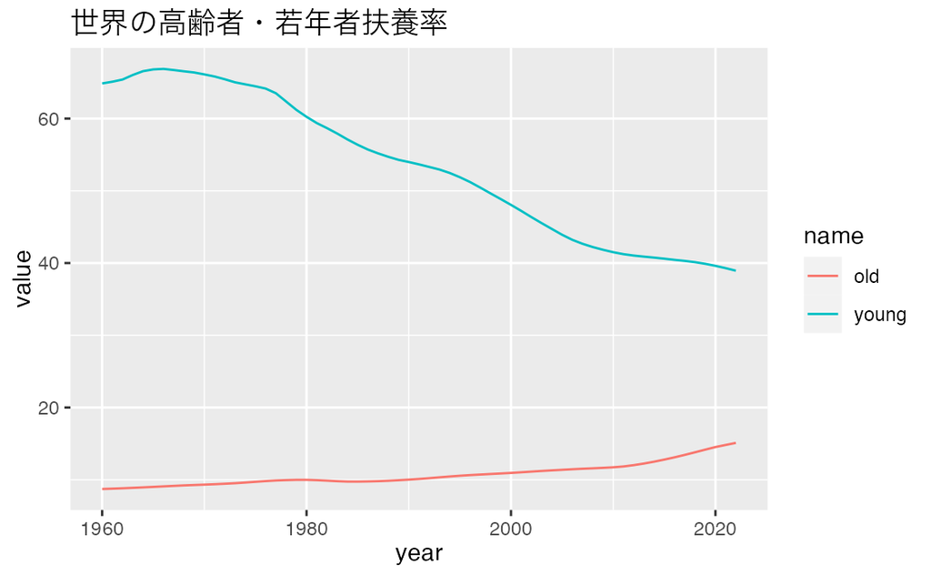

```r
df_pop_long |> filter(name %in% c("young", "old")) |>
  filter(country == "World") |>
  ggplot(aes(year, value, col = name)) + geom_line() +
  labs(title = "世界の高齢者・若年者扶養率")
```

**練習7. 国を選択して、高齢者・若年者の扶養率のグラフを描いてください。**

```r
df_pop_long |> filter(name %in% c("young", "old")) |>
  filter(country == "World") |>
  ggplot(aes(year, value, col = name)) + geom_line() +
  labs(title = "世界の高齢者・若年者扶養率")
```

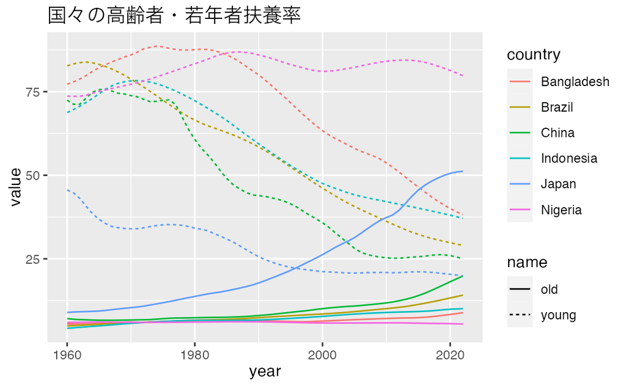

```r
df_pop_long |> filter(name %in% c("young", "old")) |>
  filter(iso2c %in% c("BD", "BR", "CN", "ID", "NG", "JP")) |>
  ggplot(aes(year, value, col = country, linetype = name)) +
  geom_line() + labs(title = "国々の高齢者・若年者扶養率")
```

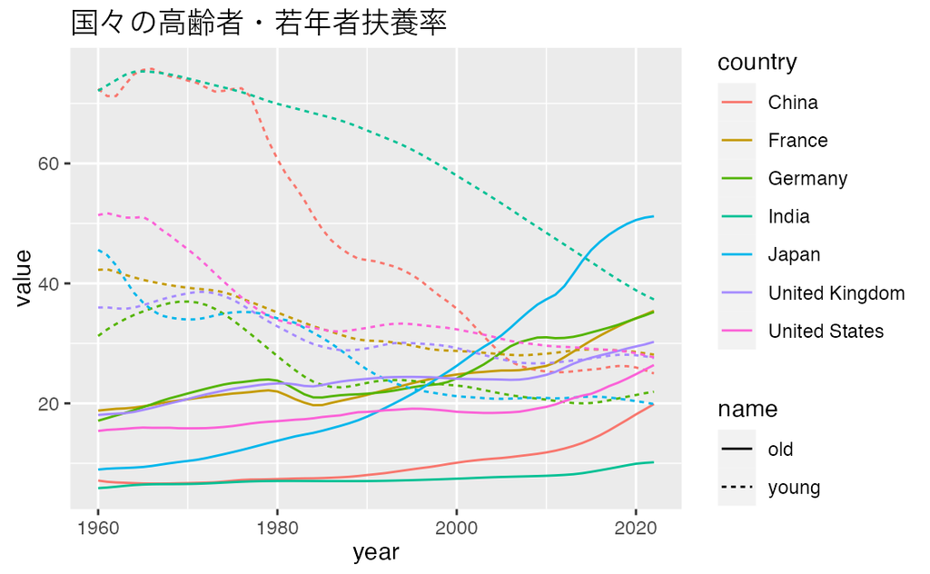

```r
df_pop_long |> filter(name %in% c("young", "old")) |>
  filter(iso2c %in% c("US", "GB", "CN", "DE", "FR", "JP", "IN")) |>
  ggplot(aes(year, value, col = country, linetype = name)) +
  geom_line() + labs(title = "国々の高齢者・若年者扶養率")
```

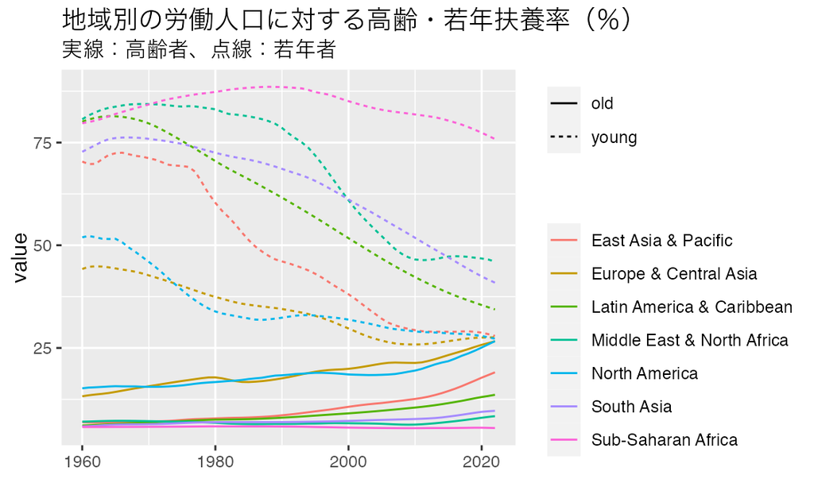

```r
df_pop_long |> filter(name %in% c("young", "old")) |>
  filter(country %in% c("South Asia", "Europe & Central Asia", "Middle East & North Africa",
"East Asia & Pacific", "Sub-Saharan Africa", "Latin America & Caribbean", "North America")) |>
  ggplot(aes(year, value, col = country, linetype = name)) +
  geom_line() + labs(title = "地域別の労働人口に対する高齢・若年扶養率（％）",
       subtitle = "実線：高齢者、点線：若年者", x = "", col = "", linetype = "")
```

**練習8. いくつかの国または地域の、高齢者・若年者の扶養率のグラフを描いてください。**

```r
df_pop_long |> filter(name %in% c("young", "old")) |>
  filter(iso2c %in% c("US", "GB", "CN", "DE", "FR", "JP", "IN")) |>
  ggplot(aes(year, value, col = country, linetype = name)) +
  geom_line()　+ labs(title = "国々の高齢者・若年者扶養率")
```

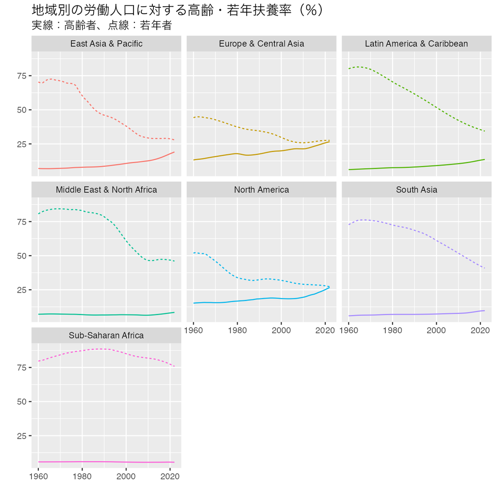

```r
df_pop_long |> filter(name %in% c("young", "old")) |>
  filter(country %in% c("South Asia", "Europe & Central Asia", "Middle East & North Africa",
"East Asia & Pacific", "Sub-Saharan Africa", "Latin America & Caribbean", "North America")) |>
  ggplot(aes(year, value, col = country, linetype = name)) +
  geom_line() + facet_wrap(~country) + theme(legend.position = "none") +
  labs(title = "地域別の労働人口に対する高齢・若年扶養率（％）",
       subtitle = "実線：高齢者、点線：若年者", x = "", y = "")
```

Default is **fig.** **width = 7 and fig.** **height = 5**

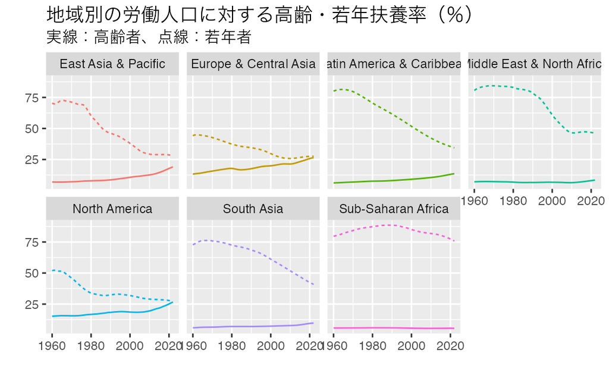

```r
df_pop_long |> filter(name %in% c("young", "old")) |>
  filter(country %in% c("South Asia", "Europe & Central Asia", "Middle East & North Africa",
"East Asia & Pacific", "Sub-Saharan Africa", "Latin America & Caribbean", "North America")) |>
  ggplot(aes(year, value, col = country, linetype = name)) +
  geom_line() + facet_wrap(~country, 2,4) + theme(legend.position = "none") +
  labs(title = "地域別の労働人口に対する高齢・若年扶養率（％）",
       subtitle = "実線：高齢者、点線：若年者", x = "", y = "")
```

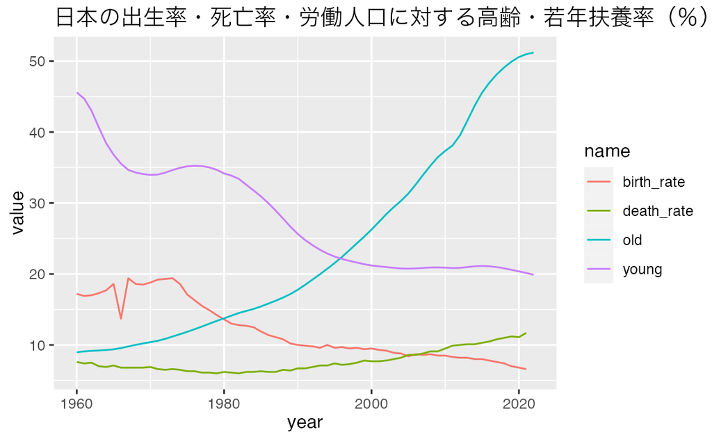

```r
df_pop_long |> filter(name %in% c("birth_rate", "death_rate", "young", "old")) |>
  filter(country == "Japan") |> drop_na(value) |>
  ggplot(aes(year, value, col = name)) + geom_line() +
  labs(title = "日本の出生率・死亡率・労働人口に対する高齢・若年扶養率（％）")
```

**練習7. 国を選択し（ドイツを変更し）て、高齢者・若年者の扶養率のグラフを描いてください。**

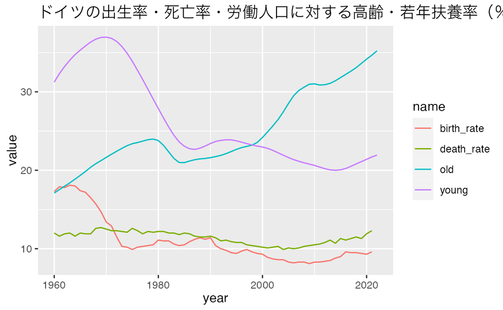

```r
df_pop_long |> filter(name %in% c("birth_rate", "death_rate", "young", "old")) |>
  filter(country == "Germany") |> drop_na(value) |>
  ggplot(aes(year, value, col = name)) + geom_line() +
  labs(title = "ドイツの出生率・死亡率・労働人口に対する高齢・若年扶養率（％）")
```

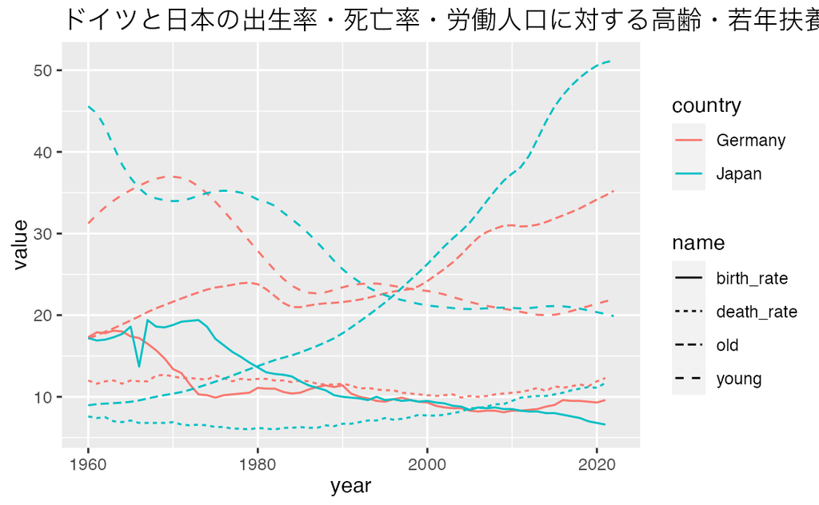

```r
df_pop_long |> filter(name %in% c("birth_rate", "death_rate", "young", "old")) |>
  filter(country  %in%  c("Germany", "Japan")) |> drop_na(value) |>
  ggplot(aes(year, value, col = country, linetype = name)) + geom_line() +
  labs(title = "ドイツと日本の出生率・死亡率・労働人口に対する高齢・若年扶養率（％）")
```

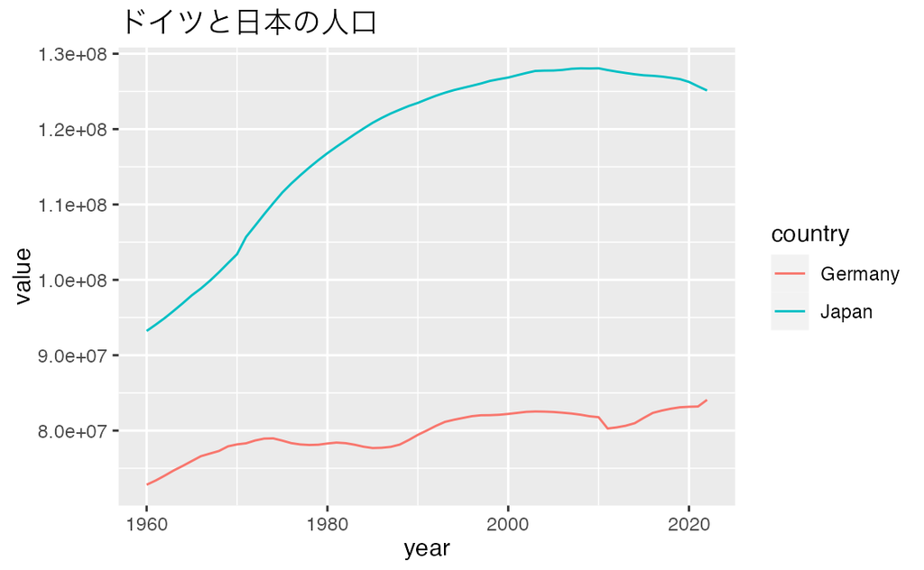

```r
df_pop_long |> filter(name == "pop") |>
  filter(country  %in%  c("Germany", "Japan")) |> drop_na(value) |>
  ggplot(aes(year, value, col = country)) + geom_line() +
  labs(title = "ドイツと日本の人口")
```

**問い：どんなことがわかりますか。**

**練習8. （ドイツと日本を変更し）いくつかの国または地域の、高齢者・若年者の扶養率のグラフを描いてください。**

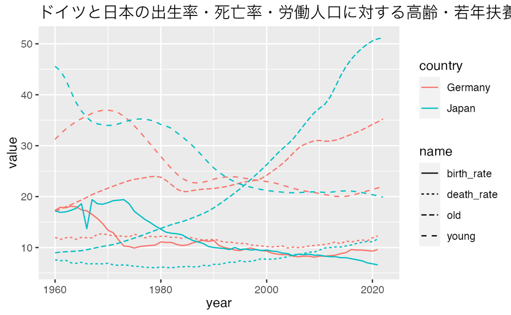

```r
df_pop_long |> filter(name %in% c("birth_rate", "death_rate", "young", "old")) |>
  filter(country  %in%  c("Germany", "Japan")) |> drop_na(value) |>
  ggplot(aes(year, value, col = country, linetype = name)) + geom_line() +
  labs(title = "ドイツと日本の出生率・死亡率・労働人口に対する高齢・若年扶養率（％）")
```

## 復習

- パッケージ（Package）の利用：
  - インストール（installation）：Tools > Install Packages
  - ロード（load）`library(tidyverse); library(WDI); library(showtext)`
- データの取得：`WDI(indicator = c(pop = "SP.POP.TOTL"))`
- 特定の行の取得：`filter(), drop_na(), distinct()`
- 折れ線グラフ
  - `ggplot(aes(x = year, y = pop) + geom_line()`
  - `ggplot(aes(x = year, y = pop, col = country) + geom_line()`

## 課題・練習

提出はしなくて良いですが、ぜひ実際に手を動かして実行してください。考えたこと、疑問があれば、記録しておいてください。

## 参考文献

1. 「みんなのデータサイエンス - Data Science for All」[[はじめてのデータサイエンス](https://icu-hsuzuki.github.io/ds4aj/first-example.html#first-example)]
   - 導入として、GDP（国内総生産）のデータを使って説明しています。
2. Posit Primers: The Basics 対話型の演習サイトの最初 [[Link](https://posit.cloud/learn/primers/1)]
   1. [Visualization Basics](https://posit.cloud/learn/primers/1.1)
   2. [Programming Basics](https://posit.cloud/learn/primers/1.2)
3. RStudio IDE Cheat Sheet. 早見表です。印刷して使うために、PDF も提供しています。[[Site Link](https://rstudio.github.io/cheatsheets/html/rstudio-ide.html)]